# Using Activity Tracker Data to Study Exercise Techniques

Aditya Iyengar

15/04/2020

## Introduction

This is a part of the course project for the course **Practical Machine Learning** offered by *Johns Hopkins University* on Coursera as a part of the Data Science Specialization.

Using devices such as Jawbone Up, Nike FuelBand, and Fitbit, it is now possible to collect a large amount of data about personal activity relatively inexpensively. These type of devices are part of the **quantified self movement** – a group of enthusiasts who take measurements about themselves regularly to improve their health, to find patterns in their behavior, or because they are tech geeks. One thing that people regularly do is quantify *how much* of a particular activity they do, but they rarely quantify *how well* they do it. In this project, we have with us data from accelerometers on the belt, forearm, arm, and dumb-bell of 6 participants. They were asked to perform bar-bell lifts correctly and incorrectly in 5 different ways. More information is available from the website [here](http://groupware.les.inf.puc-rio.br/har) (see the section on the Weight Lifting Exercise Dataset).

## Objective

The goal of the project is to predict the manner in which the people did the exercise. This is the “classe” variable in the training set. The prediction model will be used to predict 20 different test cases.

## Preliminaries

Let us load the training and test datasets.

```r
training <- read.csv("pml-training.csv")
test <- read.csv("pml-testing.csv")
```

Here are the dimensions of the training dataset.

```r
dim(training)
```

```
## [1] 19622   160
```

```r
missingindex <- which(colSums(is.na(training) |training=="")>0.9*dim(training)[1])
training <- training[,-missingindex]
training <- training[,-c(1:7)]
missingindex2 <- which(colSums(is.na(test) |test=="")>0.9*dim(test)[1])
test <- test[, -missingindex2]
test <- test[, -c(1:7)]
```

Let us now view a brief summary of the training dataset.

```r
str(training)
```

```
## 'data.frame':    19622 obs. of  53 variables:
##  $ roll_belt           : num  1.41 1.41 1.42 1.48 1.48 1.45 1.42 1.42 1.43 1.45 ...
##  $ pitch_belt          : num  8.07 8.07 8.07 8.05 8.07 8.06 8.09 8.13 8.16 8.17 ...
##  $ yaw_belt            : num  -94.4 -94.4 -94.4 -94.4 -94.4 -94.4 -94.4 -94.4 -94.4 -94.4 ...
##  $ total_accel_belt    : int  3 3 3 3 3 3 3 3 3 3 ...
##  $ gyros_belt_x        : num  0 0.02 0 0.02 0.02 0.02 0.02 0.02 0.02 0.03 ...
##  $ gyros_belt_y        : num  0 0 0 0 0.02 0 0 0 0 0 ...
##  $ gyros_belt_z        : num  -0.02 -0.02 -0.02 -0.03 -0.02 -0.02 -0.02 -0.02 -0.02 0 ...
##  $ accel_belt_x        : int  -21 -22 -20 -22 -21 -21 -22 -22 -20 -21 ...
##  $ accel_belt_y        : int  4 4 5 3 2 4 3 4 2 4 ...
##  $ accel_belt_z        : int  22 22 23 21 24 21 21 21 24 22 ...
##  $ magnet_belt_x       : int  -3 -7 -2 -6 -6 0 -4 -2 1 -3 ...
##  $ magnet_belt_y       : int  599 608 600 604 600 603 599 603 602 609 ...
##  $ magnet_belt_z       : int  -313 -311 -305 -310 -302 -312 -311 -313 -312 -308 ...
##  $ roll_arm            : num  -128 -128 -128 -128 -128 -128 -128 -128 -128 -128 ...
```

[output cut: 39 more lines]

We now partition our training dataset into separate training and test datasets.

```r
library(caret)
set.seed(11111)
inTrain <- createDataPartition(training$classe, p=0.7, list=FALSE)
traindata <- training[inTrain,]
testdata <- training[-inTrain,]
dim(traindata)
```

```
## [1] 13737    53
```

```r
dim(testdata)
```

```
## [1] 5885   53
```

## Training

### Decision Tree

```r
library(rattle)
crossvalidation <- trainControl(method="cv", number=5)
model_dt <- train(classe ~ ., data = traindata, method = "rpart", trControl = crossvalidation)
pred_dt <- predict(model_dt, newdata = testdata)
conf_dt <- confusionMatrix(testdata$classe, pred_dt)
conf_dt$table
```

```
##           Reference
## Prediction    A    B    C    D    E
##          A 1523   22  123    0    6
##          B  497  375  267    0    0
##          C  453   33  540    0    0
##          D  454  157  353    0    0
##          E  155  155  296    0  476
```

```r
conf_dt$overall
```

```
##       Accuracy          Kappa  AccuracyLower  AccuracyUpper   AccuracyNull
##      0.4951572      0.3398960      0.4823034      0.5080158      0.5237043
## AccuracyPValue  McnemarPValue
##      0.9999945            NaN
```

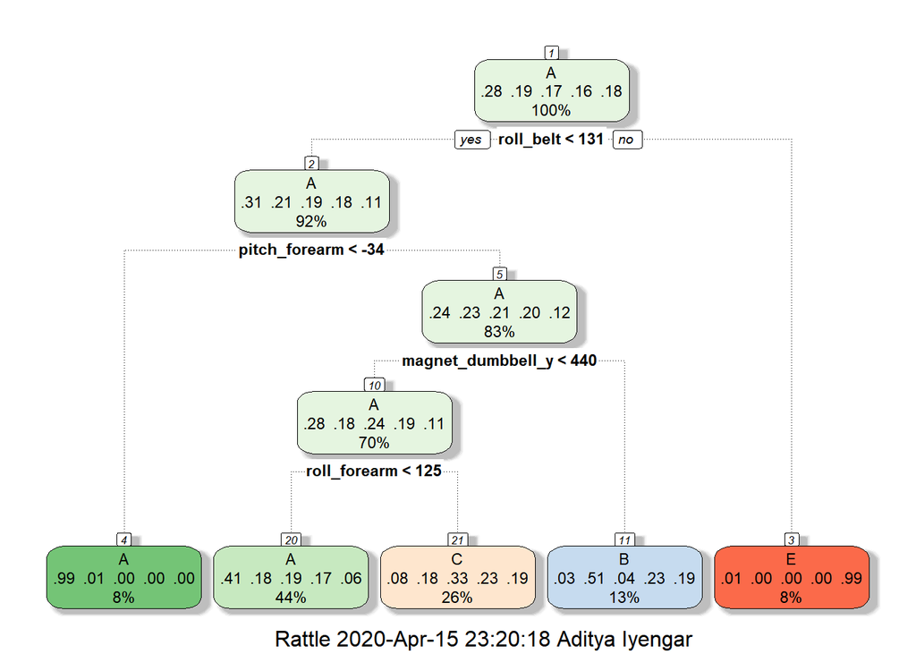

```r
fancyRpartPlot(model_dt$finalModel)
```

The accuracy obtained is **under 50%** and is extremely unsatisfactory. It would not be acceptable to use this model for further predictions.

### Random Forest

```r
library(randomForest)
model_rf <- train(classe ~ ., data = traindata, method = "rf", trControl = crossvalidation, verbose = FALSE)
pred_rf <- predict(model_rf, testdata)
conf_rf <- confusionMatrix(testdata$classe, pred_rf)
conf_rf$table
```

```
##           Reference
## Prediction    A    B    C    D    E
##          A 1674    0    0    0    0
##          B    7 1132    0    0    0
##          C    0    9 1017    0    0
##          D    0    0   14  950    0
##          E    0    0    0    3 1079
```

```r
conf_rf$overall
```

```
##       Accuracy          Kappa  AccuracyLower  AccuracyUpper   AccuracyNull
##      0.9943925      0.9929059      0.9921340      0.9961370      0.2856415
## AccuracyPValue  McnemarPValue
##      0.0000000            NaN
```

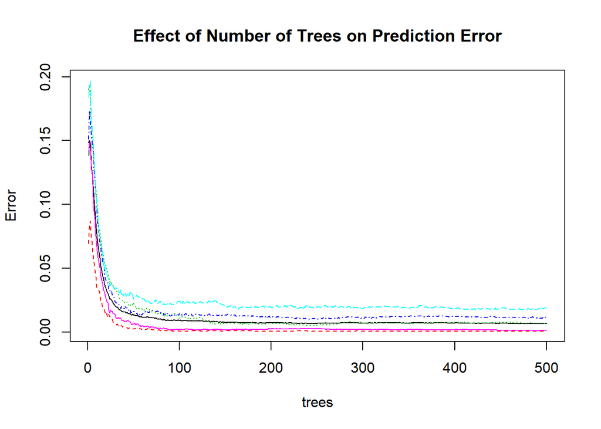

```r
plot(model_rf$finalModel, main="Effect of Number of Trees on Prediction Error")
```

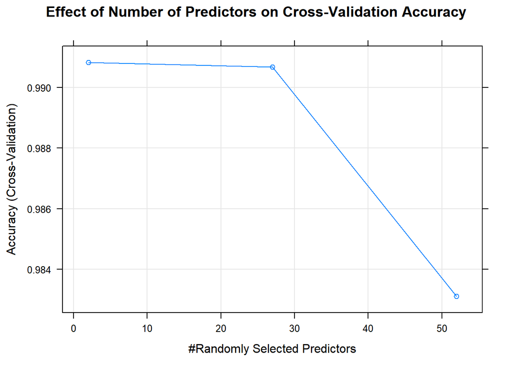

```r
plot(model_rf, main="Effect of Number of Predictors on Cross-Validation Accuracy")
```

The accuracy obtained is **over 99%**, hence this appears to be an excellent predictor.

We also see that the error in the model reduces rapidly until the number of trees are around 30. Increasing the number of trees further doesn’t have a major increment in the accuracy.

The optimal number of predictors can be anywhere from 2 to around 25. Increasing the number of predictors further reduces the accuracy, suggesting that there may be interdependent predictors that may be strongly correlated.

### Gradient Boosting

```r
model_gb <- train(classe ~ ., data = training, method = "gbm", trControl = crossvalidation, verbose=FALSE)
pred_gb <- predict(model_gb, testdata)
conf_gb <- confusionMatrix(testdata$classe, pred_gb)
conf_gb$table
```

```
##           Reference
## Prediction    A    B    C    D    E
##          A 1658   14    0    2    0
##          B   25 1093   21    0    0
##          C    0   20  991   13    2
##          D    1    2   21  939    1
##          E    2   10    9   14 1047
```

```r
conf_rf$overall
```

[output not shown]

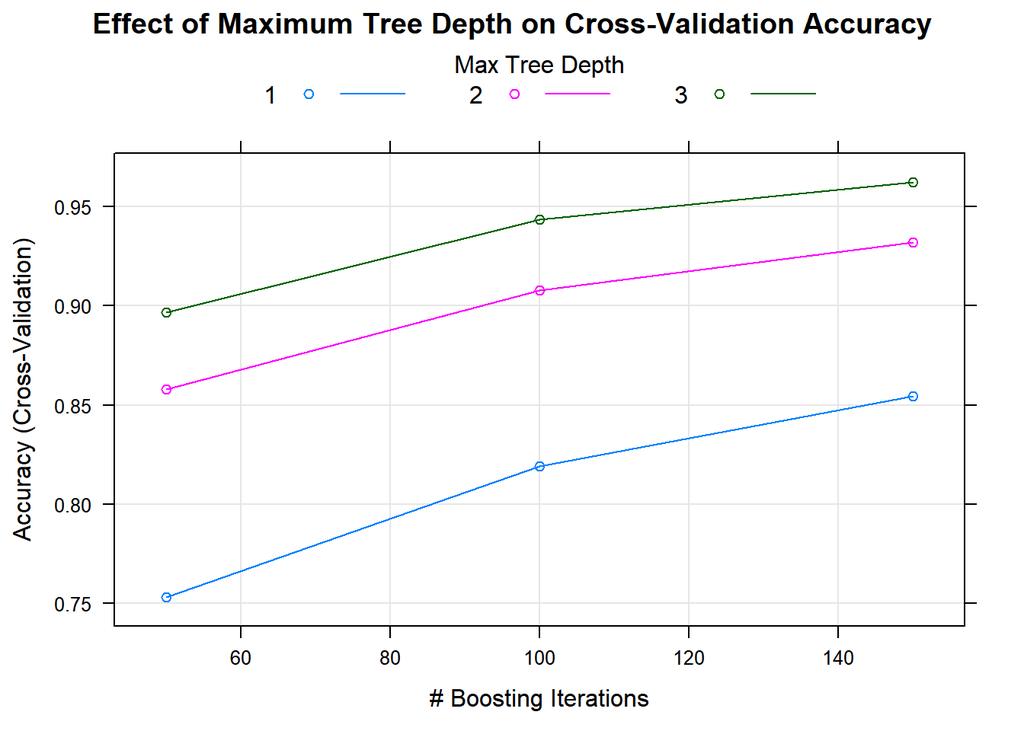

```r
plot(model_gb, main = "Effect of Maximum Tree Depth on Cross-Validation Accuracy")
```

### Support Vector Machine

```r
library(e1071)
model_svm <- svm(classe~., data = traindata, type = "C-classification", kernel = "radial", cost = 5, cross = 10)
pred_svm <- predict(model_svm, testdata)
conf_svm <- confusionMatrix(testdata$classe, pred_svm)
conf_svm$table
```

```
##           Reference
## Prediction    A    B    C    D    E
##          A 1669    4    1    0    0
##          B   22 1112    3    0    2
##          C    1   12 1011    2    0
##          D    0    0   58  906    0
##          E    0    0    5   14 1063
```

```r
conf_svm$overall
```

```
##       Accuracy          Kappa  AccuracyLower  AccuracyUpper   AccuracyNull
##      0.9789295      0.9733368      0.9749289      0.9824449      0.2875106
## AccuracyPValue  McnemarPValue
##      0.0000000            NaN
```

## Testing

We test our Random Forest model against the unseen test data that consists of 20 rows of observations.

```r
predict(model_rf, test)
```

```
##  [1] B A B A A E D B A A B C B A E E A B B B
## Levels: A B C D E
```

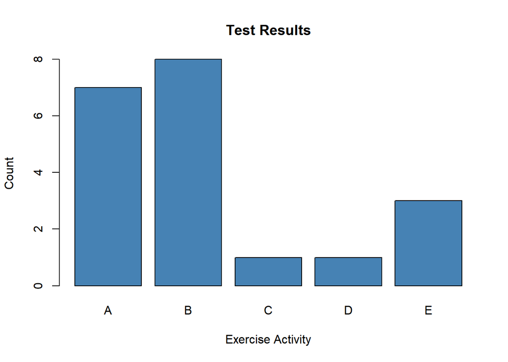

```r
plot(predict(model_rf, test), main = "Test Results", ylab = "Count", xlab = "Exercise Activity", col = "steelblue")
```

Interestingly, our SVM and GB models also give identical results as can be seen below. However the results of the Decision tree are quite some way off.

```r
predict(model_svm, test)
```

```
##  1  2  3  4  5  6  7  8  9 10 11 12 13 14 15 16 17 18 19 20
##  B  A  B  A  A  E  D  B  A  A  B  C  B  A  E  E  A  B  B  B
## Levels: A B C D E
```

```r
predict(model_gb, test)
```

```
##  [1] B A B A A E D B A A B C B A E E A B B B
## Levels: A B C D E
```

```r
predict(model_dt, test)
```

```
##  [1] C A C A A C C A A A C C C A C A A A A C
## Levels: A B C D E
```

## References

Velloso, E.; Bulling, A.; Gellersen, H.; Ugulino, W.; Fuks, H. [Qualitative Activity Recognition of Weight Lifting Exercises](http://web.archive.org/web/20161224072740/http:/groupware.les.inf.puc-rio.br/work.jsf?p1=11201) - Proceedings of 4th International Conference in Cooperation with SIGCHI (Augmented Human ’13), Stuttgart, Germany: ACM SIGCHI, 2013.